# Assignment 2 - Logistic Regression Model

Marketing 2

19 June 2026

# 1. Introduction

This R Markdown document presents the Logistic Regression model used to predict customer recommendation behaviour for Gelugor Fashion Store. The target variable is `recommend_index`, where customers are classified as either `Recommend` or `Not_Recommend`. The `Not_Recommend` class is treated as the positive class in the confusion matrix because it represents loyalty-risk customers who may require targeted improvement actions.

# 2. Load Dataset

```r
final_ml_dataset <- read_csv("final_ml_dataset.csv")

dim(final_ml_dataset)
```

```
## [1] 22627   175
```

```r
str(final_ml_dataset)
```

[output not shown]

[output cut: 225 more lines]

[output not shown]

```r
summary(final_ml_dataset)
```

[output not shown]

[output cut: 253 more lines]

```
##  Max.   :1.000000   Max.   :1.000000   Max.   :1.000000   Max.   :1.0000000
##       asap               blah              potato             badly
##  Min.   :0.000000   Min.   :0.000000   Min.   :0.000000   Min.   :0.000000
##  1st Qu.:0.000000   1st Qu.:0.000000   1st Qu.:0.000000   1st Qu.:0.000000
##  Median :0.000000   Median :0.000000   Median :0.000000   Median :0.000000
##  Mean   :0.001061   Mean   :0.001458   Mean   :0.001547   Mean   :0.002077
##  3rd Qu.:0.000000   3rd Qu.:0.000000   3rd Qu.:0.000000   3rd Qu.:0.000000
##  Max.   :1.000000   Max.   :1.000000   Max.   :1.000000   Max.   :1.000000
##       ruin               drab             cheaply
##  Min.   :0.000000   Min.   :0.000000   Min.   :0.000000
##  1st Qu.:0.000000   1st Qu.:0.000000   1st Qu.:0.000000
##  Median :0.000000   Median :0.000000   Median :0.000000
##  Mean   :0.003182   Mean   :0.001237   Mean   :0.001237
##  3rd Qu.:0.000000   3rd Qu.:0.000000   3rd Qu.:0.000000
##  Max.   :1.000000   Max.   :1.000000   Max.   :1.000000
```

```r
head(final_ml_dataset)
```

```
## # A tibble: 6 × 175
##   recommend_index rating sentiment_score   age alike_feedback_count age_group
##             <dbl>  <dbl>           <dbl> <dbl>                <dbl> <chr>
## 1               1      5               1    40                    0 middle
## 2               1      5               3    62                   12 senior
## 3               0      1               1    47                    3 middle
## 4               1      5               4    45                    0 middle
## 5               1      5              -1    37                    0 middle
## 6               1      4               4    43                    0 middle
## # ℹ 169 more variables: department_name <chr>, class_name <chr>,
## #   feedback_count_group <dbl>, division_name <chr>, amaze <dbl>, fit <dbl>,
## #   jeans <dbl>, pair <dbl>, purchase <dbl>, color <dbl>, fall <dbl>,
## #   flatter <dbl>, lovely <dbl>, model <dbl>, photo <dbl>, shame <dbl>,
## #   soft <dbl>, true <dbl>, unique <dbl>, winter <dbl>, design <dbl>,
## #   love <dbl>, meh <dbl>, black <dbl>, buy <dbl>, perfect <dbl>, size <dbl>,
## #   slightly <dbl>, look <dbl>, odd <dbl>, piece <dbl>, simple <dbl>, …
```

## Target Distribution Before Conversion

```r
table(final_ml_dataset$recommend_index)
```

```
##
##     0     1
##  4101 18526
```

```r
prop.table(table(final_ml_dataset$recommend_index))
```

```
##
##         0         1
## 0.1812436 0.8187564
```

# 3. Convert Target Variable

The target variable is converted from `0` and `1` into meaningful labels. A value of `0` represents `Not_Recommend`, while a value of `1` represents `Recommend`.

```r
final_ml_dataset$recommend_index <- factor(
  as.character(final_ml_dataset$recommend_index),
  levels = c("0", "1"),
  labels = c("Not_Recommend", "Recommend")
)

table(final_ml_dataset$recommend_index)
```

```
##
## Not_Recommend     Recommend
##          4101         18526
```

```r
prop.table(table(final_ml_dataset$recommend_index))
```

```
##
## Not_Recommend     Recommend
##     0.1812436     0.8187564
```

```r
str(final_ml_dataset$recommend_index)
```

```
##  Factor w/ 2 levels "Not_Recommend",..: 2 2 1 2 2 2 2 2 2 2 ...
```

# 4. Data Type Preparation

Character predictors are converted into factors so that they can be used properly in the Logistic Regression model.

```r
final_ml_dataset <- final_ml_dataset %>%
  mutate(
    across(where(is.character), as.factor)
  )

str(final_ml_dataset)
```

```
## tibble [22,627 × 175] (S3: tbl_df/tbl/data.frame)
##  $ recommend_index     : Factor w/ 2 levels "Not_Recommend",..: 2 2 1 2 2 2 2 2 2 2 ...
##  $ rating              : num [1:22627] 5 5 1 5 5 4 5 5 5 5 ...
##  $ sentiment_score     : num [1:22627] 1 3 1 4 -1 4 8 1 5 8 ...
##  $ age                 : num [1:22627] 40 62 47 45 37 43 79 34 49 49 ...
##  $ alike_feedback_count: num [1:22627] 0 12 3 0 0 0 4 2 4 0 ...
##  $ age_group           : Factor w/ 5 levels "adult","elderly",..: 3 4 3 3 3 3 2 1 3 3 ...
##  $ department_name     : Factor w/ 6 levels "Bottoms","Dresses",..: 1 5 1 1 3 5 5 5 5 5 ...
##  $ class_name          : Factor w/ 20 levels "Blouses","Casual bottoms",..: 8 1 16 14 19 18 18 9 5 9 ...
##  $ feedback_count_group: num [1:22627] 1 1 1 1 1 1 1 1 1 1 ...
##  $ division_name       : Factor w/ 3 levels "General","General Petite",..: 1 2 2 2 3 1 1 1 2 1 ...
##  $ amaze               : num [1:22627] 1 0 0 0 0 0 0 0 0 0 ...
##  $ fit                 : num [1:22627] 1 1 0 1 1 0 1 0 0 0 ...
##  $ jeans               : num [1:22627] 1 0 0 0 0 1 0 0 0 0 ...
##  $ pair                : num [1:22627] 1 0 0 0 0 0 0 0 0 0 ...
```

[output cut: 86 more lines]

# 5. Stratified Train-Test Split

The dataset is split into 70% training data and 30% testing data using stratified sampling. This helps maintain the proportion of `Recommend` and `Not_Recommend` customers in both the training and testing sets.

```r
set.seed(123)

sample_index <- createDataPartition(
  final_ml_dataset$recommend_index,
  p = 0.7,
  list = FALSE
)

train_data <- final_ml_dataset[sample_index, ]
test_data  <- final_ml_dataset[-sample_index, ]

dim(train_data)
```

```
## [1] 15840   175
```

```r
dim(test_data)
```

```
## [1] 6787  175
```

```r
table(train_data$recommend_index)
```

```
##
## Not_Recommend     Recommend
##          2871         12969
```

```r
table(test_data$recommend_index)
```

```
##
## Not_Recommend     Recommend
##          1230          5557
```

# 6. Build Logistic Regression Model

Logistic Regression is used because the target variable is binary. The model estimates the probability that a customer belongs to the `Recommend` class.

```r
logit_model <- glm(
  recommend_index ~ .,
  data = train_data,
  family = binomial
)

summary(logit_model)
```

```
##
## Call:
## glm(formula = recommend_index ~ ., family = binomial, data = train_data)
##
## Coefficients: (5 not defined because of singularities)
##                               Estimate Std. Error z value Pr(>|z|)
## (Intercept)                 -8.700e+00  6.057e-01 -14.364  < 2e-16 ***
## rating                       2.798e+00  7.167e-02  39.048  < 2e-16 ***
## sentiment_score              5.006e-02  2.375e-02   2.108 0.035040 *
## age                          8.238e-03  1.102e-02   0.747 0.454819
## alike_feedback_count        -2.240e-02  1.033e-02  -2.168 0.030173 *
## age_groupelderly             3.563e-01  4.803e-01   0.742 0.458148
## age_groupmiddle              5.706e-02  1.586e-01   0.360 0.718983
## age_groupsenior             -1.044e-03  3.085e-01  -0.003 0.997300
## age_groupyoung               2.802e-02  2.174e-01   0.129 0.897467
## department_nameDresses      -3.006e-01  2.423e-01  -1.241 0.214749
## department_nameIntimate     -8.956e-01  6.531e-01  -1.371 0.170243
## department_nameJackets      -1.189e+00  4.348e-01  -2.734 0.006256 **
## department_nameTops         -2.018e-01  2.578e-01  -0.783 0.433803
## department_nameTrend        -1.099e-01  5.657e-01  -0.194 0.845981
## class_nameCasual bottoms     9.201e+00  3.247e+02   0.028 0.977396
## class_nameChemises           8.322e+00  3.247e+02   0.026 0.979556
## class_nameDresses                   NA         NA      NA       NA
## class_nameFine gauge         5.228e-02  2.388e-01   0.219 0.826714
## class_nameIntimates          8.388e-01  6.212e-01   1.350 0.176911
## class_nameJackets            6.787e-01  4.615e-01   1.471 0.141383
## class_nameJeans              1.344e-01  3.433e-01   0.391 0.695482
## class_nameKnits             -8.470e-02  1.499e-01  -0.565 0.572001
## class_nameLayering           5.712e-04  6.278e-01   0.001 0.999274
## class_nameLegwear            8.413e-01  6.973e-01   1.207 0.227620
## class_nameLounge             6.412e-01  4.434e-01   1.446 0.148101
## class_nameOuterwear                 NA         NA      NA       NA
## class_namePants             -5.463e-01  2.868e-01  -1.905 0.056744 .
## class_nameShorts            -5.164e-01  4.235e-01  -1.219 0.222706
## class_nameSkirts                    NA         NA      NA       NA
## class_nameSleep              4.332e-01  5.955e-01   0.728 0.466904
## class_nameSweaters          -1.077e-01  2.135e-01  -0.505 0.613836
## class_nameSwim                      NA         NA      NA       NA
## class_nameTrend                     NA         NA      NA       NA
## feedback_count_group         2.173e-01  3.784e-01   0.574 0.565722
```

[output cut: 162 more lines]

```
## potato                       6.282e-01  1.243e+00   0.505 0.613236
## badly                       -1.653e-01  6.150e-01  -0.269 0.788160
## ruin                        -4.378e-01  5.486e-01  -0.798 0.424933
## drab                        -3.252e-01  8.276e-01  -0.393 0.694357
## cheaply                     -1.600e+00  9.530e-01  -1.679 0.093191 .
## ---
## Signif. codes:  0 '***' 0.001 '**' 0.01 '*' 0.05 '.' 0.1 ' ' 1
##
## (Dispersion parameter for binomial family taken to be 1)
##
##     Null deviance: 14993.6  on 15839  degrees of freedom
## Residual deviance:  3989.8  on 15644  degrees of freedom
## AIC: 4381.8
##
## Number of Fisher Scoring iterations: 11
```

# 7. Predict Probabilities and Classes

The model predicts the probability of a customer being classified as `Recommend`. A threshold of 0.5 is used to convert predicted probabilities into class labels.

```r
pred_prob <- predict(
  logit_model,
  newdata = test_data,
  type = "response"
)

head(pred_prob)
```

```
##         1         2         3         4         5         6
## 0.9992025 0.9944776 0.9971878 0.1655093 0.9982423 0.9997661
```

```r
pred_class <- ifelse(
  pred_prob > 0.5,
  "Recommend",
  "Not_Recommend"
)

pred_class <- factor(
  pred_class,
  levels = c("Not_Recommend", "Recommend")
)

test_data$recommend_index <- factor(
  test_data$recommend_index,
  levels = c("Not_Recommend", "Recommend")
)

head(pred_class)
```

```
##             1             2             3             4             5
##     Recommend     Recommend     Recommend Not_Recommend     Recommend
##             6
##     Recommend
## Levels: Not_Recommend Recommend
```

# 8. Confusion Matrix

The confusion matrix evaluates how many customers were correctly and incorrectly classified. The positive class is set as `Not_Recommend` because this group represents loyalty-risk customers.

```r
conf_matrix <- confusionMatrix(
  data = pred_class,
  reference = test_data$recommend_index,
  positive = "Not_Recommend"
)

conf_matrix
```

```
## Confusion Matrix and Statistics
##
##                Reference
## Prediction      Not_Recommend Recommend
##   Not_Recommend           998       194
##   Recommend               232      5363
##
##                Accuracy : 0.9372
##                  95% CI : (0.9312, 0.9429)
##     No Information Rate : 0.8188
##     P-Value [Acc > NIR] : < 2e-16
##
##                   Kappa : 0.7859
##
##  Mcnemar's Test P-Value : 0.07303
##
##             Sensitivity : 0.8114
##             Specificity : 0.9651
##          Pos Pred Value : 0.8372
##          Neg Pred Value : 0.9585
##              Prevalence : 0.1812
##          Detection Rate : 0.1470
##    Detection Prevalence : 0.1756
##       Balanced Accuracy : 0.8882
##
##        'Positive' Class : Not_Recommend
##
```

## Key Classification Metrics

```r
accuracy  <- conf_matrix$overall["Accuracy"]
precision <- conf_matrix$byClass["Pos Pred Value"]
recall    <- conf_matrix$byClass["Sensitivity"]

f1_score <- 2 * (precision * recall) / (precision + recall)

accuracy
```

```
##  Accuracy
## 0.9372329
```

```r
precision
```

```
## Pos Pred Value
##      0.8372483
```

```r
recall
```

```
## Sensitivity
##   0.8113821
```

```r
f1_score
```

```
## Pos Pred Value
##      0.8241123
```

## Save Confusion Matrix Table

```r
logit_cm_table <- as.data.frame(conf_matrix$table)

logit_cm_table
```

```
##      Prediction     Reference Freq
## 1 Not_Recommend Not_Recommend  998
## 2     Recommend Not_Recommend  232
## 3 Not_Recommend     Recommend  194
## 4     Recommend     Recommend 5363
```

```r
write_csv(logit_cm_table, "LogisticRegression_ConfusionMatrix_Table.csv")
```

## Confusion Matrix Heatmap

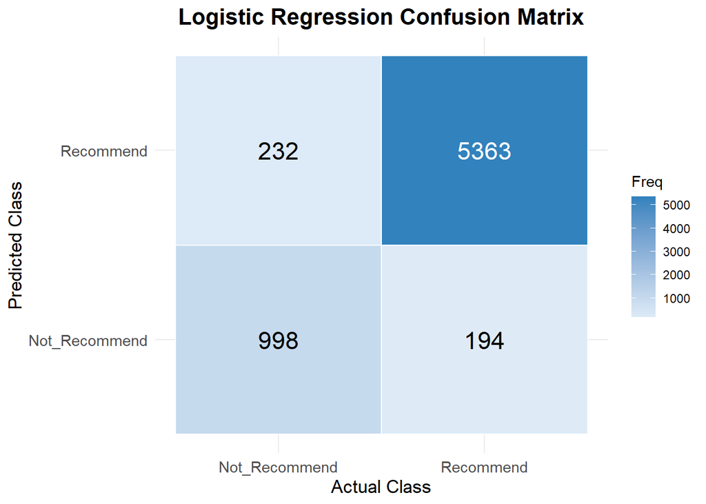

```r
logit_cm_plot <- ggplot(logit_cm_table, aes(x = Reference, y = Prediction, fill = Freq)) +
  geom_tile(color = "white", linewidth = 0.5) +
  geom_text(
    aes(
      label = Freq,
      colour = ifelse(Freq > max(Freq) / 2, "white", "black")
    ),
    size = 6
  ) +
  scale_colour_identity() +
  scale_fill_gradient(
    low = "#DEEBF7",
    high = "#3182BD"
  ) +
  labs(
    title = "Logistic Regression Confusion Matrix",
    x = "Actual Class",
    y = "Predicted Class",
    fill = "Freq"
  ) +
  theme_minimal() +
  theme(
    plot.title = element_text(size = 16, face = "bold", hjust = 0.5),
    axis.title = element_text(size = 13),
    axis.text = element_text(size = 11)
  )

logit_cm_plot
```

```r
ggsave(
  "LogisticRegression_ConfusionMatrix.png",
  logit_cm_plot,
  width = 6,
  height = 5,
  dpi = 300
)
```

# 9. Feature Importance Using Coefficients

The coefficients of the Logistic Regression model show the direction and strength of each predictor. Positive coefficients increase the probability of the `Recommend` class, while negative coefficients decrease it.

```r
logit_coef <- coef(logit_model)

logit_coef
```

```
##                 (Intercept)                      rating
##               -8.6997872666                2.7984462050
##             sentiment_score                         age
##                0.0500569333                0.0082384741
##        alike_feedback_count            age_groupelderly
##               -0.0223993954                0.3563123297
##             age_groupmiddle             age_groupsenior
##                0.0570579202               -0.0010437037
##              age_groupyoung      department_nameDresses
##                0.0280203188               -0.3006070461
##     department_nameIntimate      department_nameJackets
##               -0.8956223839               -1.1886791270
##         department_nameTops        department_nameTrend
##               -0.2017750317               -0.1098945167
##    class_nameCasual bottoms          class_nameChemises
##                9.2013496387                8.3216703813
##           class_nameDresses        class_nameFine gauge
##                          NA                0.0522786722
##         class_nameIntimates           class_nameJackets
##                0.8388153852                0.6786673025
##             class_nameJeans             class_nameKnits
##                0.1343678537               -0.0847046382
##          class_nameLayering           class_nameLegwear
##                0.0005711932                0.8412757580
##            class_nameLounge         class_nameOuterwear
##                0.6412253588                          NA
##             class_namePants            class_nameShorts
##               -0.5463422461               -0.5163568174
##            class_nameSkirts             class_nameSleep
##                          NA                0.4332125054
##          class_nameSweaters              class_nameSwim
##               -0.1077156065                          NA
##             class_nameTrend        feedback_count_group
##                          NA                0.2173273514
## division_nameGeneral Petite      division_nameInitmates
##                0.0137427883                0.2673384061
##                       amaze                         fit
##                0.7384040179                0.1197318378
##                       jeans                        pair
##                0.2281220182                0.1295407973
```

[output cut: 147 more lines]

```
##               -0.6138317478               -1.6609521377
##                   shapeless                     concept
##               -1.6121859795               -1.3776694763
##                 instruction                    needless
##               -0.1951988131               -1.4908568553
##                      barely                additionally
##                0.2527290564               -2.8891446639
##                        asap                        blah
##               -0.8001507219               -1.5391988134
##                      potato                       badly
##                0.6282022130               -0.1652504880
##                        ruin                        drab
##               -0.4377536732               -0.3252084571
##                     cheaply
##               -1.5999760361
```

## Coefficient Table

```r
coef_table <- data.frame(
  Feature = names(logit_coef),
  Coefficient = as.numeric(logit_coef)
) %>%
  arrange(desc(abs(Coefficient)))

coef_table
```

```
##                         Feature   Coefficient
## 1      class_nameCasual bottoms  9.2013496387
## 2                   (Intercept) -8.6997872666
## 3            class_nameChemises  8.3216703813
## 4                       weirdly -3.4770082396
## 5                  additionally -2.8891446639
## 6                        rating  2.7984462050
## 7                           meh -2.2207128108
## 8                    impossible -1.8895983001
## 9                           ill -1.6609521377
## 10                      elegant  1.6138757768
## 11                    shapeless -1.6121859795
## 12                      cheaply -1.5999760361
## 13                         blah -1.5391988134
## 14                     feminine  1.5149697672
```

[output cut: 187 more lines]

```r
write_csv(coef_table, "LogisticRegression_Coefficients.csv")
```

## Top Coefficient Plot

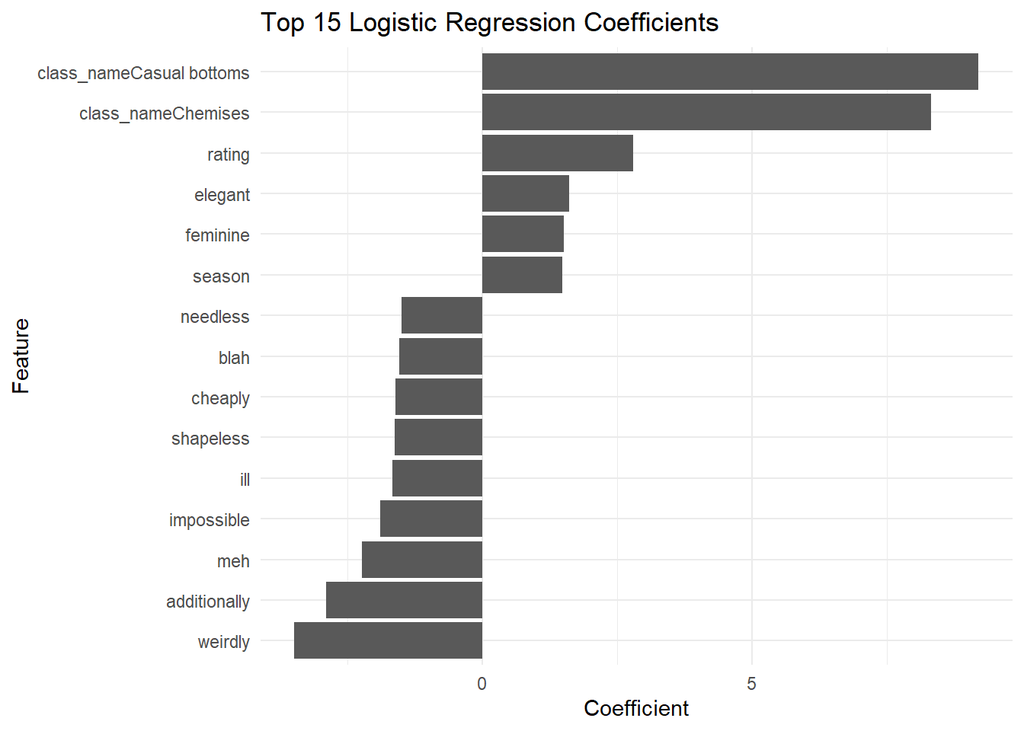

```r
top_coef <- coef_table %>%
  filter(Feature != "(Intercept)") %>%
  slice_max(order_by = abs(Coefficient), n = 15)

coef_plot <- ggplot(
  top_coef,
  aes(x = reorder(Feature, Coefficient), y = Coefficient)
) +
  geom_col() +
  coord_flip() +
  labs(
    title = "Top 15 Logistic Regression Coefficients",
    x = "Feature",
    y = "Coefficient"
  ) +
  theme_minimal()

coef_plot
```

```r
ggsave(
  "LogisticRegression_Coefficients.png",
  coef_plot,
  width = 8,
  height = 5,
  dpi = 300
)
```

# 10. ROC Curve and AUC

The ROC curve evaluates the model’s ability to separate `Recommend` and `Not_Recommend` customers. A higher AUC value indicates stronger classification separability.

```r
roc_logit <- roc(
  response = test_data$recommend_index,
  predictor = pred_prob,
  levels = c("Not_Recommend", "Recommend"),
  direction = "<"
)

auc_value <- auc(roc_logit)

auc_value
```

```
## Area under the curve: 0.9808
```

## ROC Curve Plot

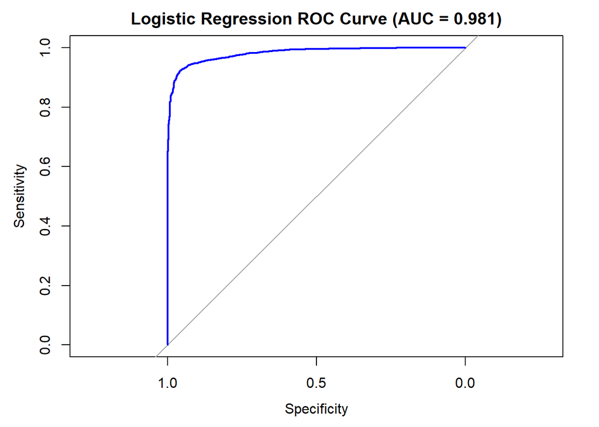

```r
plot(
  roc_logit,
  col = "blue",
  main = paste0(
    "Logistic Regression ROC Curve (AUC = ",
    round(auc_value, 3),
    ")"
  )
)
```

```r
png("LogisticRegression_ROC.png", width = 1000, height = 800, res = 150)

plot(
  roc_logit,
  col = "blue",
  main = paste0(
    "Logistic Regression ROC Curve (AUC = ",
    round(auc_value, 3),
    ")"
  )
)

dev.off()
```

# 11. Save Logistic Regression Performance Metrics

The model performance is summarized using Accuracy, Kappa, Balanced Accuracy, Recall, Specificity, Precision, F1-score and AUC. Since the business objective focuses on detecting loyalty-risk customers, Recall for `Not_Recommend` and Balanced Accuracy are important evaluation metrics.

```r
logit_metrics <- data.frame(
  Model = "Logistic Regression",
  Accuracy = as.numeric(conf_matrix$overall["Accuracy"]),
  Kappa = as.numeric(conf_matrix$overall["Kappa"]),
  Balanced_Accuracy = as.numeric(conf_matrix$byClass["Balanced Accuracy"]),
  Recall_NotRecommend = as.numeric(conf_matrix$byClass["Sensitivity"]),
  Specificity_Recommend = as.numeric(conf_matrix$byClass["Specificity"]),
  Precision_NotRecommend = as.numeric(conf_matrix$byClass["Pos Pred Value"]),
  F1_NotRecommend = as.numeric(conf_matrix$byClass["F1"]),
  AUC = as.numeric(auc_value)
)

logit_metrics
```

```
##                 Model  Accuracy     Kappa Balanced_Accuracy Recall_NotRecommend
## 1 Logistic Regression 0.9372329 0.7859243         0.8882356           0.8113821
##   Specificity_Recommend Precision_NotRecommend F1_NotRecommend       AUC
## 1             0.9650891              0.8372483       0.8241123 0.9808445
```

```r
write_csv(logit_metrics, "LogisticRegression_Metrics.csv")
```

# 12. Save Final Model

The final Logistic Regression model is saved as an RDS file so that it can be reused later for prediction or model deployment.

```r
saveRDS(logit_model, "LogisticRegression_Model.rds")
```

# 13. Conclusion

The Logistic Regression model was developed to predict whether customers would recommend a clothing item. It is useful because it provides both classification results and interpretable coefficients. The model can identify how product, customer, rating, review engagement and review-text features influence the probability of recommendation. Since `Not_Recommend` customers represent loyalty-risk customers, the model is especially useful when it achieves strong Recall for `Not_Recommend`, Balanced Accuracy and AUC.